# Report on Dr. Ekman’s Tools Feedback Survey

Charlotte Lopp

December 4, 2017

## Results and Discussion

When we looked at the metric of utility by race we saw a general trend that for each demographic, except for “Black,” the pluarlity was for a usefulness of experience score of 5 (Figure 2). The margin of difference between the number of people who scored the usefulness as a 5 versus 4 was significantly larger in participants who identified as “White” than any other ethnicity. This probably a product of the fact that vast majority of our participants identified as “White” (Figure 1). Taking a closer look at those who did not identify as “White,” we see that those who identified as “Hispanic” were the next highest in terms of percentage that scored the usefulness of experience as 5 (Figure 3). Of the 3 “Black” participants (Figure 4), there was 1 score of 3 and 2 scores of 4; it is the only demographic that did not have a single score of 5.

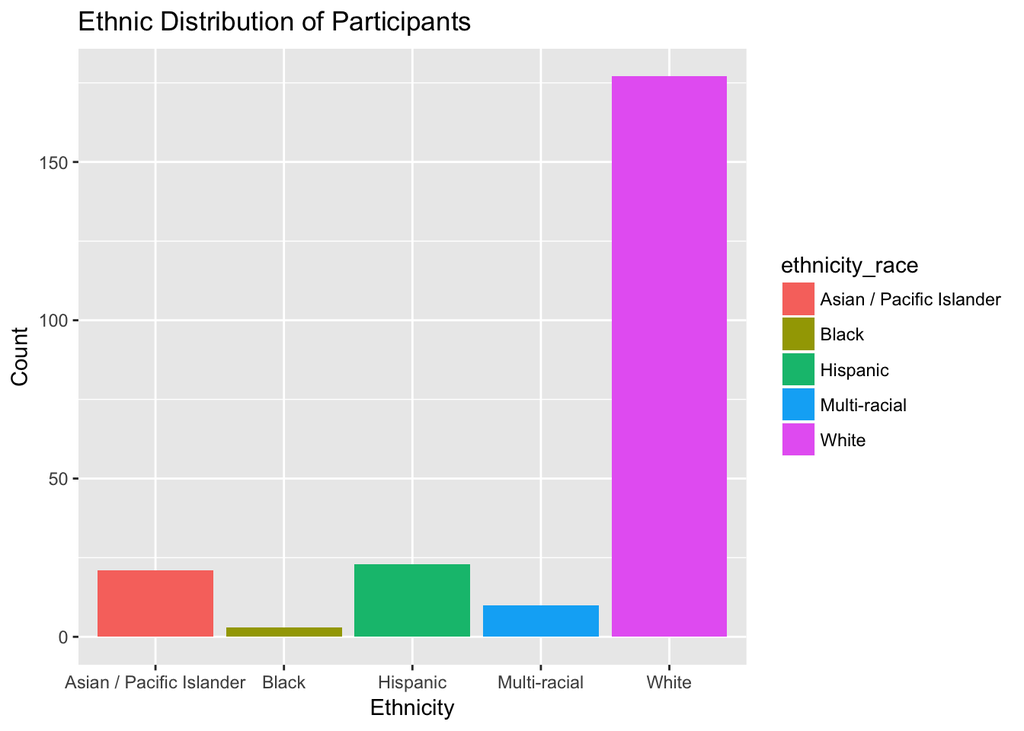

**Figure 1**: This figure shows the ethnic distribution of participants.

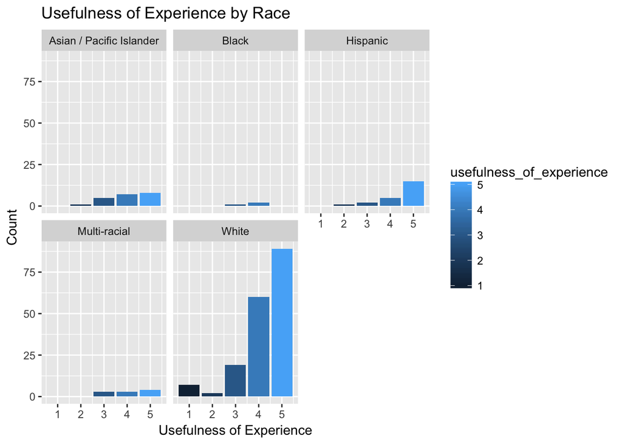

**Figure 2**: This figure shows the usefulness of experience score by ethnic groups.

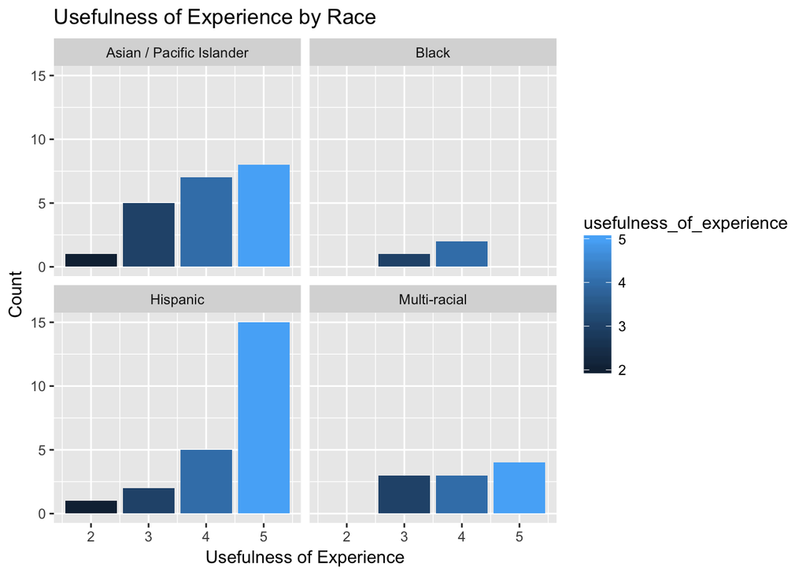

**Figure 3**: This figure shows the usefulness of experience score by all the ethnic groups other than “White.”

| ethnicity_race | n |
| --- | --- |
| Asian / Pacific Islander | 21 |
| Black | 3 |
| Hispanic | 23 |
| Multi-racial | 10 |

**Figure 4**: This table shows the total number of participants for each ethnic group for a better and more accurate understanding of Figure 3.

Curious about the trend seen in the previous figures about usefulness of experience scores, we were curious to see what correlation that had to education (Figure 5). Overall, a majority of participants had either a highest educational level of university or post graduate (Figure 5 and 15). It is interesting to note that for our participants that identified as “Black,” they all had post graduate education. For “Asian/Pacific Islander” and “Hispanic,” there was more of an even spread among high school, university, and post graduate.

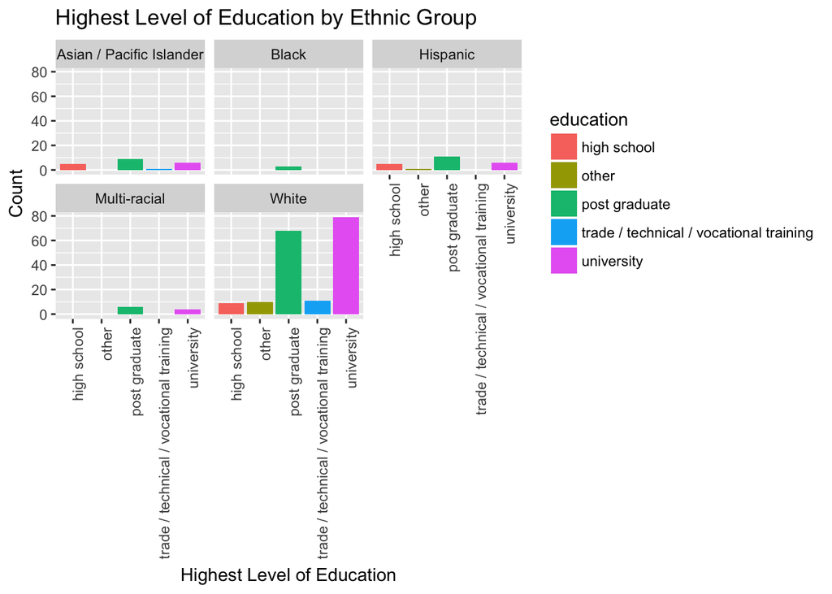

**Figure 5**: This figure shows highest level of education of participants by ethnic group.

When we looked at the monetary value evaluations for the product, we saw that every ethnic group was represented except for those that identified as “Black” (Figure 6). The general trend for all ethnicities were the scores: average, above average, and excellent. For “White” participants, the majority was in these three aforementioned evaluations. This demographic was also the only one to have evaluations of poor. “Multi-racial” were the only other participants to those that identified as “White” to evaluate the monetary value of the product as below average. “Asian/Pacific Islander” participants scored as either excellent or above average. “Hispanic” participants evaluated it as either excellent or average.

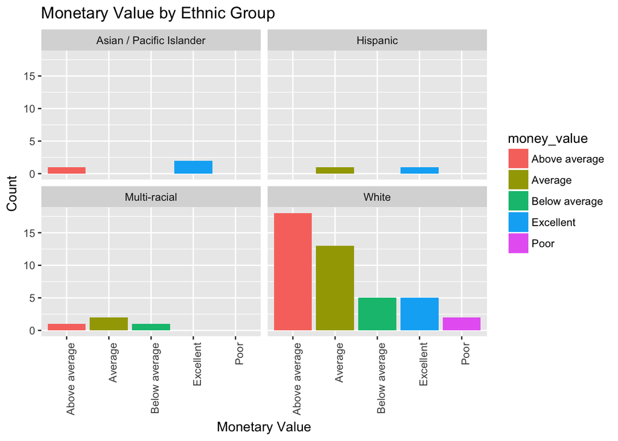

**Figure 6**: This figure shows the money value evaluation of the product by ethnic group.

In order to take a more in-depth investigation into these trends, we looked at the free answer questions by ethnic group (Figures 7-10). For those that identified as “Black,” the only response written was to answer the question asking to describe their experience where they expressed enjoyment of the course but difficulty in applying it to every day.

#### Only Participants That Indicated Race of “Black”

| gender | age | education | ethnicity_race | usefulness_of_experience | money_value | dislike | change_for_improvement | like_most | describe_experience |
| --- | --- | --- | --- | --- | --- | --- | --- | --- | --- |
| male | 19 - 29 | post graduate | Black | 4 | N/A | N/A | N/A | N/A | No answer |
| male | 30 - 49 | post graduate | Black | 3 | N/A | N/A | N/A | N/A | No answer |
| male | 50 - 64 | post graduate | Black | 4 | N/A | N/A | N/A | N/A | It is an excellent course and I thoroughly enjoyed it, unfortunately don’t often see micro expressions. |

**Figure 7**: This table shows the answers for all the participants that identified as “Black.”

#### Only Participants That Indicated Ethnicity of “Multi-racial”

| gender | age | education | ethnicity_race | usefulness_of_experience | money_value | dislike | change_for_improvement | like_most | describe_experience |
| --- | --- | --- | --- | --- | --- | --- | --- | --- | --- |
| female | 19 - 29 | university | Multi-racial | 3 | Average | N/A | N/A | N/A |  |
| male | 50 - 64 | post graduate | Multi-racial | 4 | Above average | Not enough variety of scenarios in Law enforcement, workplace and family modules | Increase number of scenarios | METT, SETT | Good feedback on each expression |
| female | 30 - 49 | university | Multi-racial | 3 | Below average | It didn’t seem to work properly, I didn’t feel like I learned anything. I felt there wasn’t enough theory and information about the reasoning behind answers. | more intuitive technology. More reasoning and theory needed. | I really didn’t like this one. Though I have done other training from you previously and have learned a lot. |  |
| male | 30 - 49 | post graduate | Multi-racial | 3 | Average | Short for the money | Video instead of pictures flashing. Maybe some diagrams pointing out which features are exactly being described when showcasing certain microexpressions. More differentiation of some of the similar on… | Good variety of faces |  |
| male | 19 - 29 | post graduate | Multi-racial | 5 | N/A | N/A | N/A | N/A | It’s an effective way to get used to micro-expressions and to spot them effectively |
| female | 19 - 29 | university | Multi-racial | 5 | N/A | N/A | N/A | N/A | Very interesting and easy to use. |
| male | 19 - 29 | post graduate | Multi-racial | 4 | N/A | N/A | N/A | N/A | No answer |
| male | 30 - 49 | university | Multi-racial | 4 | N/A | N/A | N/A | N/A | It is very interesting to understand what people really mean when they are trying to act differently. Now I have a better understanding but need a lot more practice. |
| male | 30 - 49 | post graduate | Multi-racial | 5 | N/A | N/A | N/A | N/A | Been using for about 4 years. |
| male | 30 - 49 | post graduate | Multi-racial | 5 | N/A | N/A | N/A | N/A | I always had this kind of natural observation to read people’s faces but without totally understand the meaning of them. In most cases, my mind would have noticed something was happening and tried to … |

**Figure 8**: This table shows the answers for all the participants that identified as “Multi-racial.”

Out of those that identified as “Hispanic,” only 2 of them answered the questions regarding what they disliked about their experience, what they would change for an improvement, and what they liked most. 6 of the 23 did not respond to the question asking to describe their overall experience. What they disliked was the length and digital platform. What both of them said in terms of changes for improvement would be a more mobile friendly platform. The things they liked most were being able to apply it to every day life and the content of the trainings. Their descriptions of the overall experience were very positive quoting interesting tools, usefulness and practicality, using it for teaching a college course, and being more in tune with others because of deeper understanding.

#### Only Participants That Indicated Ethnicity of “Hispanic”

| gender | age | education | ethnicity_race | usefulness_of_experience | money_value | dislike | change_for_improvement | like_most | describe_experience |
| --- | --- | --- | --- | --- | --- | --- | --- | --- | --- |
| male | 19 - 29 | high school | Hispanic | 5 | Excellent | The length, but honestly that can’t be helped. | Making it more mobile friendly I would say. Sometimes I didn’t have the time to sit at my home computer, and while I could use it on my phone, it wasn’t very easy to do so. | How I could almost immediately apply it in real life, and after going through the first training being able to recognise expressions from practice. |  |
| male | 30 - 49 | post graduate | Hispanic | 3 | Average | The digital plataform | The same. The a better digital and mobile plataform | The content and the trainings | Interesting |
| male | 30 - 49 | post graduate | Hispanic | 5 | N/A | N/A | N/A | N/A | Your is most definitely epic!! |
| male | 19 - 29 | high school | Hispanic | 3 | N/A | N/A | N/A | N/A | The training tool was okay. I believe a more natural setting will do better, as well as, more faces and a neutral face |
| male | 30 - 49 | post graduate | Hispanic | 5 | N/A | N/A | N/A | N/A | Fantastic tools |
| male | 19 - 29 | other | Hispanic | 5 | N/A | N/A | N/A | N/A | They were easily understood and actually fun to do. This has helped greatly in my line of work. |
| male | 50 - 64 | post graduate | Hispanic | 4 | N/A | N/A | N/A | N/A | Practical and interesting |
| male | 0 -18 | high school | Hispanic | 4 | N/A | N/A | N/A | N/A | No answer |
| male | 30 - 49 | university | Hispanic | 5 | N/A | N/A | N/A | N/A | No answer |
| female | 30 - 49 | post graduate | Hispanic | 5 | N/A | N/A | N/A | N/A | Fue muy importante poder descubrir los movimientos musculares, estudiarlos una y otra vez para entender las expresiones y microecpresiones humanas. Considero que el Dr Ekman ha contribuido de una mane… |
| male | 30 - 49 | post graduate | Hispanic | 5 | N/A | N/A | N/A | N/A | I used it to teach in a college course. I hve trained first and then use the tools for teaching. |
| female | 30 - 49 | university | Hispanic | 4 | N/A | N/A | N/A | N/A | i think the tool seems to be very easy but the fact it is required to invest to much time. |
| male | 19 - 29 | university | Hispanic | 4 | N/A | N/A | N/A | N/A | Great |
| male | 30 - 49 | university | Hispanic | 5 | N/A | N/A | N/A | N/A | No answer |
| male | 19 - 29 | university | Hispanic | 5 | N/A | N/A | N/A | N/A | It was very helpful. |
| female | 19 - 29 | high school | Hispanic | 5 | N/A | N/A | N/A | N/A | it took a while to understand it and see the expressions, but the voice in the background helped explained what to look for. I like how simple and easy the program is to use. |
| female | 30 - 49 | post graduate | Hispanic | 5 | N/A | N/A | N/A | N/A | No answer |
| male | 19 - 29 | high school | Hispanic | 2 | N/A | N/A | N/A | N/A | No answer |
| male | 30 - 49 | university | Hispanic | 5 | N/A | N/A | N/A | N/A | It was a great experience, I could get in tune with my emotion and those of others. I’d humbly would like to recommend more training for de subtle expression that are the one we encounter the most in … |
| female | 50 - 64 | post graduate | Hispanic | 4 | N/A | N/A | N/A | N/A | The training itself was very helpful. My greatest concern is how difficult it is to contact you, Paul Ekman Group. My email went unanswered and there is no phone number to call. |
| female | 50 - 64 | post graduate | Hispanic | 5 | N/A | N/A | N/A | N/A | Very helpful in learning to read micro expressions |
| male | 30 - 49 | post graduate | Hispanic | 5 | N/A | N/A | N/A | N/A | Awesome tools, I was able to read people more efficiently |
| male | 30 - 49 | post graduate | Hispanic | 5 | N/A | N/A | N/A | N/A | Excelente herramienta, para él área de recursos humanos y la familia ñ. |

**Figure 9**: This table shows the answers for all the participants that identified as “Hispanic.”

#### Only Participants That Indicated Ethnicity of “White”

| gender | age | education | ethnicity_race | usefulness_of_experience | money_value | dislike | change_for_improvement | like_most | describe_experience |
| --- | --- | --- | --- | --- | --- | --- | --- | --- | --- |
| male | 30 - 49 | university | White | 4 | Average | Sometimes it is hard to find time for it. Maybe an app for the smartphone would be cool (to be able to use it everywhere). | Smaller sessions. | In general it is a cool thing understanding the non-verbal language of people. |  |
| male | 30 - 49 | university | White | 4 | Average | I still love the tool but would like to have the 99 dollar one time purchasing, not annual? | 1. A life-time access for that money, until you do not change dramatically. 2. On the test please highlight the sections choosen (with another color) | The general usability of spotting expressions can be helpful and once skilled also a nightmare in once. Nevertheless, it can be helpful, but it needs a very long training periode… (and to get it in fl… | It would be helpful to have a version that runs smooth on both desktop and as web app on the smartphone. A version in German and Portuguese would be nice to see in the near future and for that reason … |
| male | 30 - 49 | university | White | 3 | Below average | This kind of one year pay-serve… | As explained, offline version, one time payment, more examples and a somehow a shift into real life situations, face plus postures plus situation….? | It makes life in general more transparent, unfortunately you will have to live from that moments onwards with this new skill… sometimes you will wish to be naive again… |  |
| male | 30 - 49 | post graduate | White | 5 | Excellent | nothing | the system does not run well over a wireless link to monitor/screen | feedback | The tools help deepen the experience and understanding of the FACS. |
| female | 30 - 49 | university | White | 5 | Above average | That it is only “flashes” and not talking sequences | That it would be real conversations (like in the tests connected to the education) - maybe it could be a thing for people who have passed the causes? | The ease of use, the “use-as-much-as-you-can” | increases learning of the micro expressions, increases the concentration level |
| male | 50 - 64 | university | White | 5 | Above average | With most on-line training you get a lifetime access, which is here not the case | see 8 | The total set up and feedback | Gives me a lot of insights about people behaviour very practical. |
| female | 30 - 49 | university | White | 4 | Above average | Nothing | I little more detail in the explanations with other expressions that might be similar | That it was all online | I found it useful for the purposes of interviewing canidates for my company and working in HR |
| male | 30 - 49 | post graduate | White | 5 | Above average | The speed of some examples was pretty high. I think an even slower option would help. More faces as well would help | Live courses in locations where I can attend. Or at least live courses I can take over high speed internet | Very applicable in real life | Loved them |
| male | 50 - 64 | university | White | 3 | Above average | sometimes difficult to notice subtle facial movements | movements | being in contact with something very different from my daily tasks |  |
| male | 50 - 64 | post graduate | White | 4 | Average | I think I tried to use it on my android tablet and it didn’t work out too well I don’t like the year expiration. The incremental cost to letting me continue to use it is negligible. You’ve gotten paid… | Some diagrams isolating the detailed features of expressions Maybe what I’d like is some FACS training How about some detection exercises in flat affect videos? We’re being taught to always alarm, whi… | The tests were fun The ability to flash the expression on and off was a function of the software | Good, but I don’t feel the training translates to everyday use that well, as expressions are micro micro, and fewer and farther between |
| male | 30 - 49 | post graduate | White | 5 | Excellent | Nothing | None. | The ability to review and go over certain areas. | It was great. Highly recommended. Thank you. |
| male | 19 - 29 | university | White | 5 | Average | They were very expensive. I understand the value lies in the research, not the programs themselves, but I would have liked some light weight tools (i.e. and app) that’s cheaper and could allow me to t… | See previous question. | Very useful tools. I loved the program. | Excellent. Worth the money, even though the tools are almost prohibitively expensive. |
| male | 50 - 64 | high school | White | 4 | Above average | NA | It is well designed. | I can do it at home. | I found myself jumping to conclusions on some things, judgement will come with time. |
| male | 30 - 49 | post graduate | White | 4 | Average | Sometimes complicated | N/A | N/A | Very good tool |
| male | 30 - 49 | post graduate | White | 4 | Below average | Nothing of note. | It would be nice to slow down the expressions sometimes | Fun to use | No answer |
| male | 30 - 49 | university | White | 4 | Below average | N/A | Using open standards and web standards giving people the freedom to use their browser on Mac, GNU/Linux or Microsoft Windows operating system. | N/A | N/A |
| female | 50 - 64 | university | White | 4 | Above average | The availability of only access it for a year. | Longer time to train, as I have a busy schedule. | I like that you can start off learning the micro expressions. | Love them. |
| male | 30 - 49 | university | White | 4 | Above average | On rare occasions I would experience issues during the testing where the expression would be stuck instead of flashing at slow, normal or fast. Sometimes it would also not flash at all. This occurred … | A phone app to make the training more mobile and easier to access would be great. | I genuinely improved my ability to recognize different micro expressions. | I am in law enforcement and with this training have been able to assist in investigations by watching subjects being interviewed. I am now observing expressions quicker and more accurately, several of… |
| male | 50 - 64 | university | White | 4 | Above average | N/A | N/A | N/A | N/A |
| male | 19 - 29 | university | White | 4 | Average | The pricing was a bit steep. Would be a okay price if it was lifetime. | The option for a mobile app, for on the go training. | To really feel that you starting to understand what you are learning. | Think it was great was easy to understand descriptions and the video material made it easy to learn the basica. |
| female | 50 - 64 | university | White | 4 | Below average | on-line–too much money for the limited product delivered | price that fits training | . | No answer |
| male | 65-100 | post graduate | White | 4 | Above average | Black man and women only expression is contempt. | Black faces other emotions too. | Good verbal and visual explanation. | Used them for 15 years in teaching support of my Master Degree courses (Stanford MBA and Austria Masters). |
| female | 30 - 49 | university | White | 4 | Average | That the system lagged at times. | More randomness and a mixture of the different trainings (face, side etc) | That I feel the feelings I am trying to detect. | I use Dr. Ekman’s training tools to prepare myself (the night before) for when I host different leadership programs and meet managers in bigger groups. Thanks to the refreshening of attunement to diff… |
| female | 50 - 64 | other | White | 4 | Above average | N/A | We need more different programs | Pic - repeat - solution function | very good, but we i would need more different programs |
| male | 30 - 49 | post graduate | White | 3 | Average | N/A | Personal / unlimited time license. Having to pay every year kind sucks. :( | N/A | N/A |
| female | 50 - 64 | trade / technical / vocational training | White | 4 | Average | It was a bit tricky being ready at the right moment for the emotion to flash- but that’s all part of the process I guess | For me personally I think some reminders during the course of the year would have been good, ie to remind me I have x amout of time left with access to the materials | Beginning to recognise things in life that I had learned on the course | It was a good experience! Solidly useful, it will help me in my life and I’m glad I took the course |
| male | 50 - 64 | university | White | 5 | Above average | Small images, could be larger. | See 8 :) | Speed with which you can practise. | Really enjoyed it! It has allowed me to really integrate the recognition of FA in my daily life, both personal and professional. Thank you! |
| male | 30 - 49 | post graduate | White | 4 | Average | n/a | n/a | Practical side | No answer |
| male | 19 - 29 | post graduate | White | 4 | Above average | limited amount of photos | add more photos of different people, otherwise after a few times one can memories the correct answers | clear and concise | Helps to understand people around |
| male | 30 - 49 | university | White | 4 | Average | Would like greater variety of profiles | More variety | The feedback | Positive |

[output cut: 147 more lines]

***Figure 10**: This table shows the answers for all the participants that identified as “White.”

### Lack of Variety and Racial Prejudice

The issue of lack of variety and racial prejudice could be addressed together by adding new photos to the set already in the product. The racial issue was that there was a number of comments on that certain demographics seemed to be only represented expressing negatively associated expressions (like anger, contempt, disgust). There could be the “prime” photos that Paul hand selected because he believed them to be best representative of the emotion in question but when it comes to just straight practicing, there can be a much larger pool of faces. A lot of people who brought up the issue of variety said they went through the photos a number of times and after such extensive practicing, they began doubting whether they were identifying the expression based on comprehension or recognition.

There’s also the issue of race. One thing that stands out to me is that race is a social construct and doesn’t in fact exist and yet we are using racial vernacular. Another thing is that, as mentioned in the first meeting, there would be value in looking at what the actual distribution is of ethnicity across the different emotions. Being a product based on and valued by its scientific integrity, I believe its also important that we show as little bias as possible. Depending on our vision and the scope of relavancy we want to encompass in terms of societal constructs and social issues, its also important to have (and ultimately teach with) an as inclusive of a tool as possible. Being able to read and understand the faces that are unlike ours (regardless of what ethnicity “ours” refers to but particularly when it comes to minorities) is so crucially integral particularly when it comes to the justice system and law enforcement - which happens to be a sector that a lot of our clients come from. MacArthur fellow and adjunct professor at Stanford University, Jennifer Eberhardt has done a lot of research on the importance of implicit racial biases and received the Genius award for her work. For us to not only be a commercial product but one whose core was founded in science, I think it is very important that we take this into consideration and really think about what message and messages we are sending and want to send.

### Technical Issues

People did not find the website user-friendly or experienced technical issues. Some would mention that they would have difficulty loading a page or the website wouldn’t acknowledge that they had completed a section. The biggest themes were that our website is not mobile-friendly so it wasn’t as easily accessible and “on-the-go” as people would have liked and that there were times when the website said there was a certificate but they did not receive one despite scoring very high on the tests. I think this is a pretty easy fix in terms of ensuring that the website is compatible in terms of refresh rates, etc with all the major browsers and that we go through whatever channels in WordPress to ensure mobile-friendly access.

### Money: Barrier to Entry

The barrier to entry issue of money could be solved in a variety of ways. People would say that they were so busy in their personal and professional lives that they didn’t have a chance to use their tools. I think a built-in aspect where if go to a help section, they will just be navigated to the option of a month extension that will be automatically granted if its their first time requesting (this will bypass the issues of customer service response time, etc.) If they go to cancel, make it simply worth it for them to keep the service – a steep discount or something like that. There could be a referral system with user-specific discount codes in order to track how people are finding out about us and why they are type buying. This would also be helpful in terms of giving us data to deal with without having to ask how they heard about us in a survey. If we don’t want to make it a cut in profit with discounts for renewing customers, there was also suggestions in the feedback sections that we provide them with something that they can continue to use after their year is up – the idea of paying so much for just one year and then no access to any of the materials after that was just not worth it for people.

Another metric we were interested in was usefulness of experience by gender (Figure 11). Here we can see that more of the participants were male. A majority for both men and women scored it as either 4 or 5 in terms of usefulness.

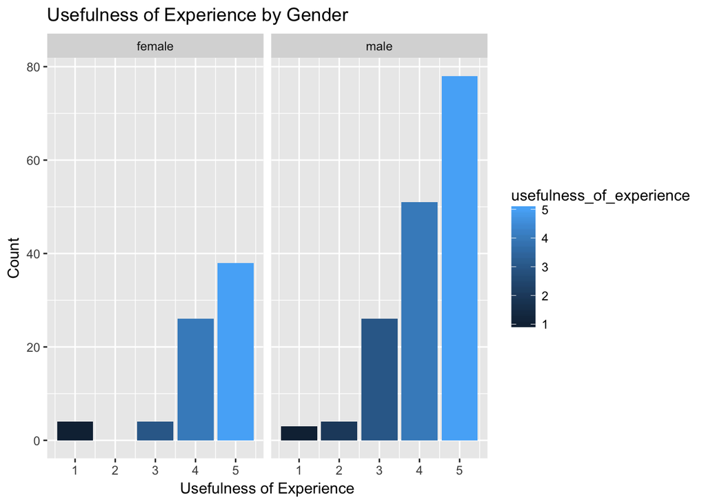

**Figure 11**: This figure shows usefulness of experience scores by gender.

When we looked at the usefulness of experience by age (Figure 12), we saw that a plurality of our participants fell within the age group of 30-49 (Figure 13). Almost all of our participants were between the ages of 19 and 64. For each age group except for 0-18, the highest count was for a usefulness score of 5. For 0-18 aged participants, it was a split between 3 and 5 for the majority. Usually the score of 4 was the next highest in terms of count but for the age group 65-100, scores of 3 and 4 were tied for second place.

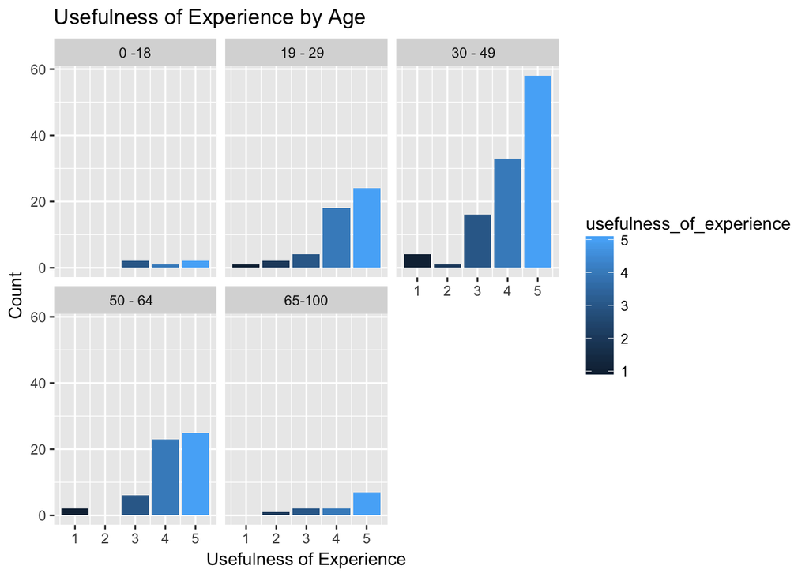

**Figure 12**: This figure shows usefulness of experience scores by age.

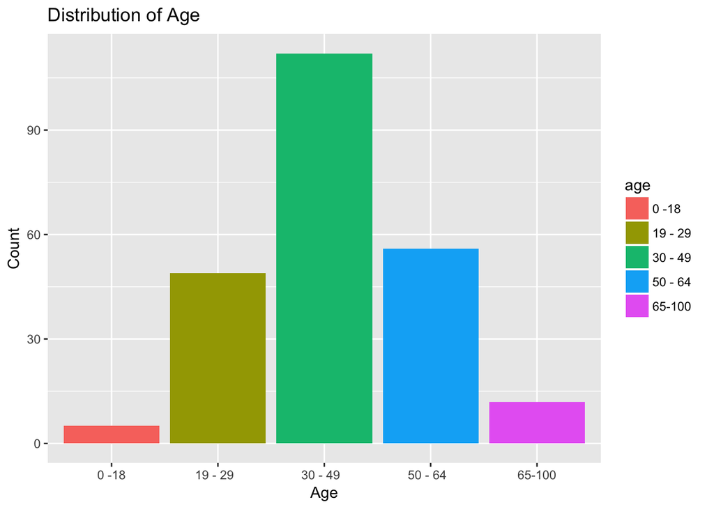

**Figure 13**: This figure shows the age distribution of participants in order to have a more accurate understanding of Figure 12.

Finally, the last thing we looked at was usefulness of experience scores by education (Figure 14). We found that for every educaton group, the majority scored either 4 or 5. As was established earlier, most of our participants had university or post graduate education (Figure 15).

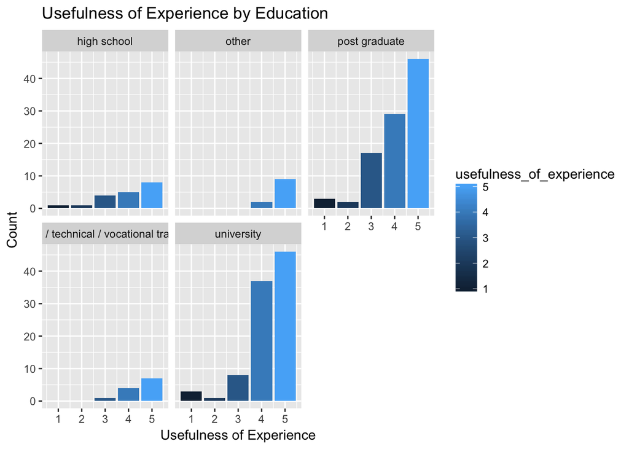

**Figure 14**: This figure shows usefulness of experience scores by education.

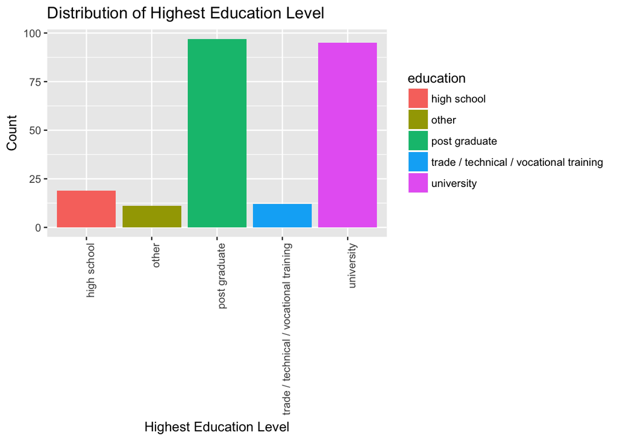

### Survey Issues/Collecting More Accurately Representative Information

Building some data gathering into the infrastructure of the website would make it much easier for us to discern trends that can be optimized upon in order to increase profit margins. Our target demographic is clear: (majority-based) male, 30-49, have university or post-graduate level education, white, and lives in the US, UK, or Canada. Getting a name, email address, zip code and country, and one or other two data points shouldn’t be that hard to do. Our product is not one of little investment - a sentiment that has been echoed by many in the Feedback Survey. If they have decided to buy the product, in order to set up their account and to use it, I am highly doubtful that they would object. Filling out those few boxes is omnipresent - our world is saturated with sign up pages for websites, products, etc. Also, there are many responses where people write their whole back story and why these tools were so valuable and useful to them - we cast a very specific net with these tools and as a result, in my opinion, catch a very dedicated group of people. I believe that detail should be noted and valued when it comes to customer participation and engagement. A referral system as previously stated would be helpful in terms of tracking what demographic our customer base lies in but would also provide incentive for current users and potentially bring us new customers that would otherwise not have bought our product. Considering we have a solid customer base in educational institutions and law enforcement, I believe the referral system would be particularly useful and helpful.